# ProgressBar

# ProgressBar shows the player numerical values as a bar

`ProgressBar` holds a value, limits it to a minimum and maximum, and draws it on the screen as a bar for the player to see.

This makes the `ProgressBar` optimal for showing ratios, percentages, and fractions to the player in a readable way.

In this guide, you will learn how to:

- Create bars that show progress or track health.
- Reflect changes in a character’s health, such as damage or healing, in the interface.
- Use a vertical bar for ability cooldowns.

Contents:

- ProgressBar’s key features
  - Limit a value
  - Round a value in steps
- How to use a ProgressBar in practice
  - Healing items
  - Showing progress through a level
  - Increasing the player’s maximum health
  - Create an ability cooldown
- Your questions
  - How do I change the color of my ProgressBar?
  - How do I use different shapes for a ProgressBar?
  - How do I keep a ProgressBar updated with my health variable?
- Pro Tips

## ProgressBar’s key features

`ProgressBar` and `TextureProgress` both inherit from the `Range` class and share its key features.

You can take the tricks you learn in this guide to other `Control` nodes that extend the `Range` class, such as `HScrollbar`, `HSlider`, and `SpinBox`.

### Limit a value

The `Range` class holds a floating-point *Value*. When the *Value* changes, it automatically limits it to be between *Min Value* and *Max Value*.

Limiting in this way can also be achieved with the `clamp()` function.

You can use this to prevent your *Value* from going below or above a certain amount.

You can let the *Value* exceed the *Max Value* or *Min Value* by enabling the *Allow Greater* and *Allow Lesser* properties.

### Round a value in steps

The *Step* property forces the *Value* to only ever be a multiple of that *Step*. When you change the *Value* property, it will be rounded to the nearest multiple of *Step*.

Setting *Step* to `1.0` will force the `ProgressBar` to increase in integers. So adding a value like `0.1` will be rounded down to `0`, creating no change.

You can also enable the *Rounded* property to force the `ProgressBar` to increase in integers, regardless of the *Step*.

You can use a `Range` in combination with player input to handle scrollbars and spinboxes. However, `ProgressBar` does not take user input, so it’s better suited to display read-only information like health and experience points.

## How to use a ProgressBar in practice

Now we’ll look at some concrete uses of a `ProgressBar`.

### Healing items

Many games have items that can restore the player’s lost health. Usually, this comes with needing extra code to limit how much health the player can gain to their maximum health.

With a `ProgressBar`, this functionality is built-in.

You can save your player’s health directly to the *Value* of a progress bar to avoid having to save it to a variable and manage it by hand. We will use a `ProgressBar`’s *Value* to act as a health variable with built-in clamping and rounding.

Using a `ProgressBar` to store health not only unifies your UI and health variables but also lets you reliably check exact values like zero or one-hundred. We’ll see an example of this later on.

Our setup includes a few extra moving parts. We will use an asteroid projectile to deal damage to the player, and a health pickup to heal ourselves.

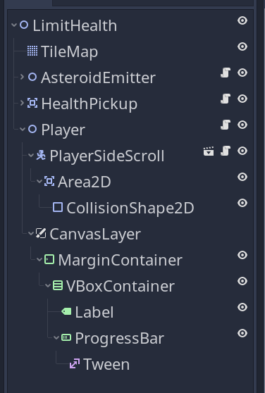

We have a sidescrolling *Player* already built, so we extended our base *Player* script and will cover how our *Player* interacts with the pickups, asteroids, and the `ProgressBar`. You can find the base *Player* scene in the Godot project here: `common/PlayerSideScroll/PlayerSideScroll.tscn`.

```
onready var _collision_area: Area2D = $Area2D

onready var _health_bar: ProgressBar = $CanvasLayer/MarginContainer/VBoxContainer/ProgressBar
onready var _health_tween: Tween = $CanvasLayer/MarginContainer/VBoxContainer/ProgressBar/Tween


func _ready() -> void:
    _collision_area.connect("area_entered", self, "_on_Area2D_area_entered")
    _collision_area.connect("body_entered", self, "_on_Area2D_body_entered")
```

We’ll be using an `Area2D` child of the *Player* for collision detection. This area will handle when we’re touching a health kit or when a projectile has hit us.

The *Projectile* will be a `RigidBody2D`, so we want to use the `body_entered` signal for it. The health kit will also be an `Area2D`, detected with the `area_entered` signal.

If we want to expand our game to feature multiple types of bodies and areas, we need a way to narrow down the areas and bodies we find. We chose to solve this using class names.

Our health kit’s `class_name` is `HealthKit`, and our asteroid’s `class_name` is `Projectile`. We can check if a `Node` is a given class using the `is` keyword.

```
func _on_Area2D_area_entered(area: Area2D) -> void:
    if area is HealthKit:
        if _health_bar.value != _health_bar.max_value:
            heal(area.health_given)
            area.pickup()


func _on_Area2D_body_entered(body: Node) -> void:
    if body is Projectile:
        take_damage(body.damage)
        body.destroy()
```

Instead of adjusting the *Value* property of the `ProgressBar` directly, we’re using a `Tween`. This makes the loss of health look smoother, and it helps the player see how much health they just lost or gained.

```
func heal(amount: int) -> void:
    _health_tween.interpolate_property(
        _health_bar,
        "value",
        _health_bar.value,
        _health_bar.value + amount,
        0.5,
        Tween.TRANS_CUBIC,
        Tween.EASE_OUT
    )
    _health_tween.start()
```

Animating damage like this is not ideal for incredibly competitive games and can make using a separate health variable necessary. However, it pairs well with giving your player some invulnerability frames where they can’t take damage for a short time after being hurt.

Also, since we used a `ProgressBar` and our *Min Value* is zero, we can reliably check if the *Value* is equal to zero without fear of floating-point rounding errors or negative health values.

```
func take_damage(amount: int) -> void:
    _health_tween.interpolate_property(
        _health_bar,
        "value",
        _health_bar.value,
        _health_bar.value - amount,
        0.5,
        Tween.TRANS_CUBIC,
        Tween.EASE_IN_OUT
    )
    _health_tween.start()
    yield(_health_tween, "tween_all_completed")
    if _health_bar.value == 0:
        die()


func die() -> void:
    queue_free()
```

For the sake of brevity, we kill our player with `queue_free()`. A better solution is to set the player into a “dead” state where their animations and movements are locked. This makes it easier to re-start the player without reloading the entire scene. To learn more about creating states like a death state, check out our complete guide to making *Finite State Machines* in Godot: [the Finite State Machine design pattern](https://www.gdquest.com/tutorial/godot/design-patterns/finite-state-machine/)

We deal damage to the player when they come into contact with a `RigidBody2D` with the `class_name` *Projectile*.

[figure not shown]

Here’s how we set up the health kit:

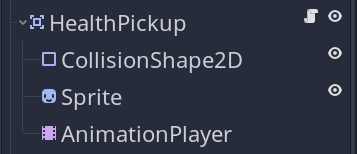

```
class_name HealthKit
extends Area2D

const PLAYER_LAYER := 0

export var health_given: int = 50

onready var _anim_player: AnimationPlayer = $AnimationPlayer
```

When the player touches this area and determines it’s a health kit, the player calls a `pickup()` function on this script.

This function prevents the player from picking the health kit up multiple times and makes the health kit disappear for a while. We used an `AnimationPlayer` to queue up animations to disappear, wait, and respawn.

```
func pickup() -> void:
    set_collision_layer_bit(PLAYER_LAYER, false)
    _anim_player.stop()
    _anim_player.queue("collected")
    _anim_player.queue("delay")
    _anim_player.queue("respawn")
```

The “respawn” animation features a method call track for a `respawn()` method, which re-enables the player collision layer for the health kit, and starts the idle animation again.

```
func respawn() -> void:
    set_collision_layer_bit(PLAYER_LAYER, true)
    _anim_player.play("idle")
```

### Showing progress through a level

Some racing games and platformers will show how far you are through a level as you complete the stage.

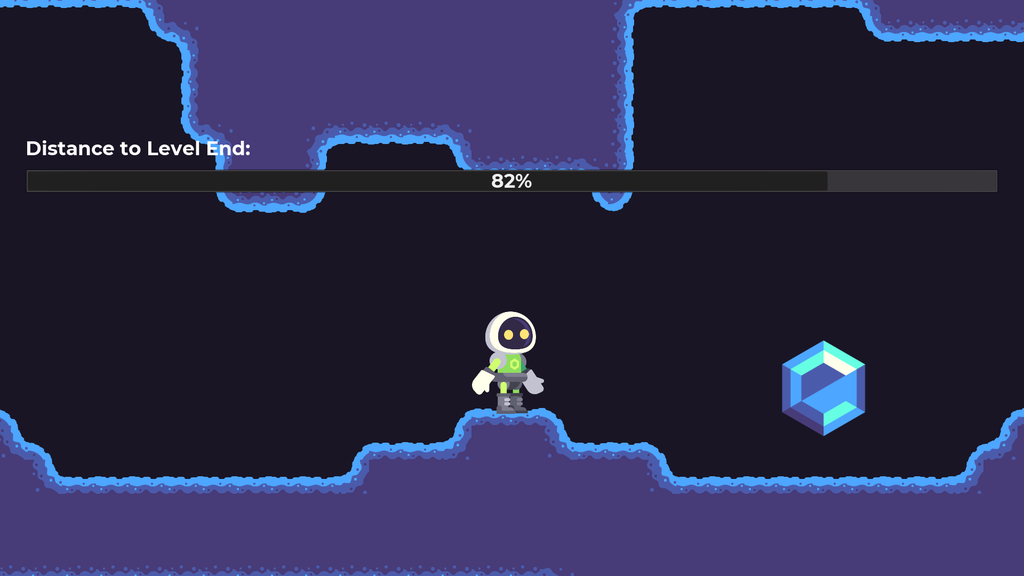

To have a `ProgressBar` show your player’s progress throughout the stage, we can place two `Position2D` nodes to show us the start and end of our level.

Later, we will use `inverse_lerp()` to get our player’s proximity to these two nodes as a ratio.

We’ve added a `CanvasLayer` as a child of our player to hold our user interface. Being a child of the player lets us call functions on the `ProgressBar` directly, avoiding emitting and connecting signals for our UI.

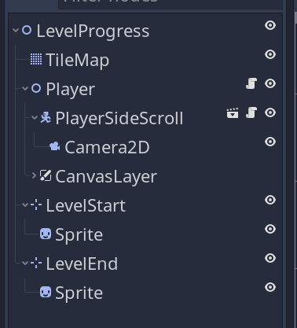

Here is the script that gets the x coordinates of our `Position2D` nodes:

```
export var level_start_path: NodePath
export var level_end_path: NodePath

onready var _level_start: float = get_node(level_start_path).global_position.x
onready var _level_end: float = get_node(level_end_path).global_position.x

onready var _player: KinematicBody2D = $PlayerSideScroll
onready var _progress_bar: ProgressBar = $CanvasLayer/MarginContainer/VBoxContainer/ProgressBar
```

Now to set the *ProgressBar Value*, we’ll use `set_as_ratio()`. This function takes a value between `0.0` and `1.0`. This updates the *Value* to be that ratio between its minimum and maximum values. For example, `set_as_ratio`(`0.5`) would make our *Value* halfway between our minimum and maximum.

Using `inverse_lerp()` we can turn our positions into a ratio for the `ProgressBar`.

If we pass in our minimum and maximum x coordinates and the player’s x coordinate, the inverse lerp function will return a ratio from `0.0` to `1.0`, showing how close the player is to the start and end positions.

```
func _process(_delta: float) -> void:
    # Sets the progress bar to a ratio from 0.0 to 1.0, depending on how close the player is to the level_end, relative to the level_start.
    _progress_bar.set_as_ratio(inverse_lerp(_level_start, _level_end, _player.global_position.x))
```

### Increasing the player’s maximum health

There are many games where your maximum health can increase with in-game progression: *God* of *War*, *Prince* of *Persia*, *Hades*, and many more.

On top of holding the health variable as its *Value*, a `ProgressBar` is an excellent choice to handle upgrading your maximum health.

Usually, the `ProgressBar` size stays the same when increasing the *Max Value*. But this makes the current *Value* look smaller. You can fix this in a few ways, such as adding a label indicating the *Value*.

We chose to increase the `ProgressBar`’s `rect size`, keeping in line with action games where health bars can grow across the screen.

We used an instanced scene for the maximum health pickup so multiple pickups can be present in the game.

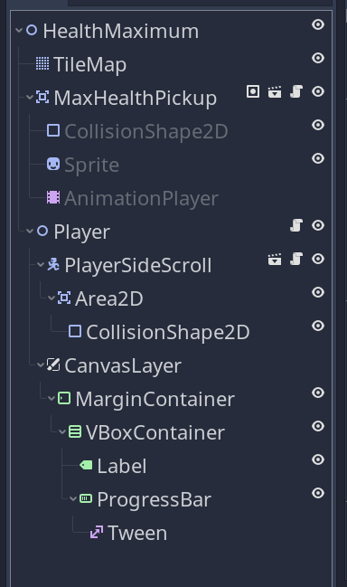

Like holding health in a `ProgressBar`’s *Value*, we’re using a separate script that doesn’t interfere with our preset player controller. You can find `common/PlayerSideScroll/PlayerSideScroll.tscn` in the Godot project we provided.

The `MAX_HEALTH` constant is here to prevent us from gaining infinite maximum health and having the health bar go off-screen.

```
extends Node2D

const MAX_HEALTH := 300

onready var _player: KinematicBody2D = $PlayerSideScroll
onready var _collision_area: Area2D = $PlayerSideScroll/Area2D

onready var _health_bar: ProgressBar = $CanvasLayer/MarginContainer/VBoxContainer/ProgressBar
onready var _health_tween: Tween = $CanvasLayer/MarginContainer/VBoxContainer/ProgressBar/Tween

onready var _anim_player: AnimationPlayer = $PlayerSideScroll/PlayerSideSkin/AnimationPlayer
```

We use the `area_entered` signal from the player’s `Area2D` to detect the health pickup:

```
func _ready() -> void:
    _collision_area.connect("area_entered", self, "_on_Area2D_area_entered")


func _on_Area2D_area_entered(area: Area2D) -> void:
    if area.is_in_group("pickup"):
        increase_max_health(area.health_given)
        area.pickup()
```

And we can delegate increasing the maximum health to a new function.

This function is where the `MAX_HEALTH` check happens, so we can’t get infinite health. Then, we use the `Tween` child to increase both the *Max Value* and the progress bar’s `rect_min_size`.

We increase the minimum size to ensure the bar increases its size regardless of if it is in a container.

```
func increase_max_health(amount: int) -> void:
    if _health_bar.max_value >= MAX_HEALTH:
        return

    _health_tween.interpolate_property(
        _health_bar,
        "max_value",
        _health_bar.max_value,
        _health_bar.max_value + amount,
        0.5,
        Tween.TRANS_CUBIC,
        Tween.EASE_OUT
    )

    _health_tween.interpolate_property(
        _health_bar,
        "rect_min_size:x",
        _health_bar.rect_min_size.x,
        (_health_bar.max_value + amount) * 5,
        0.5,
        Tween.TRANS_CUBIC,
        Tween.EASE_OUT
    )
    _health_tween.start()
```

We can provide a `health_given` variable for the pickup script to determine how much our maximum health should increase.

```
extends Area2D

const PLAYER_LAYER := 0

onready var _anim_player: AnimationPlayer = $AnimationPlayer

export var health_given: int = 50
```

Then, we need to create a `pickup()` function called by the player when they pick up the health upgrade.

```
func pickup() -> void:
    set_collision_layer_bit(PLAYER_LAYER, false)
    _anim_player.stop()
    _anim_player.queue("collected")
    _anim_player.queue("delay")
    _anim_player.queue("respawn")


func respawn() -> void:
    set_collision_layer_bit(PLAYER_LAYER, true)
    _anim_player.play("idle")
```

The `respawn()` function is called using the `AnimationPlayer` child of the health upgrade.

### Create an ability cooldown

In hero shooters or MOBA games, it’s common to find character abilities that recharge after being used.

A `TextureProgress` bar will show a portion of a texture using its *Value* property. The *Fill Mode* lets you choose how the texture is displayed as the *Value* increases.

[figure not shown]

*Game: Overwatch (2016)*

For this guide, instead of creating a script on the scene root, we’ll be creating a script on a `TextureProgress`. When this script is done, the exported variables can be used to customize any `TextureProgress` this script is applied to, as long as it has a `Tween` and `AnimationPlayer` as a child.

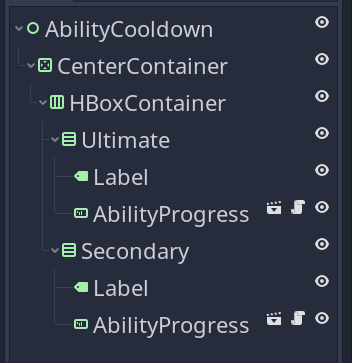

Each instanced *AbilityProgress* scene has a `Tween` and an `AnimationPlayer`.

We animate this `TextureProgress` node in two ways. First, the `Tween` will move the *TextureProgress Value* from zero to one-hundred percent. Second, the `AnimationPlayer` will change the *Tint Progress* and *Tint Under* properties to make the bar flash when activated.

```
extends TextureProgress

export var time_to_recharge: float = 3.0
# A shortcut lets us easily customize the input event that triggers the animation.
export var action_to_activate: ShortCut
# We use Tween to refill the bar's value over several seconds.
onready var _tween: Tween = $Tween
# We use AnimationPlayer to change the bar's tint colors, just for visual flair.
onready var _anim_player: AnimationPlayer = $AnimationPlayer


func _ready() -> void:
    value = max_value
```

We added a `ShortCut` export here so each `TextureProgress` can have a unique *InputAction* assigned in the *Inspector*.

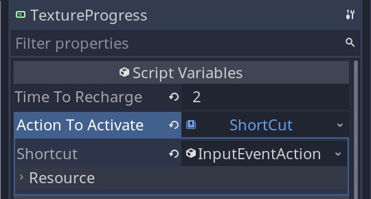

The `ShortCut` is a built-in resource you can attach to any `Control` node. You assign it an input action, and when the player presses it, it pushes or activates the corresponding UI element. It’s a convenient tool to assign keyboard shortcuts to buttons and other UI elements.

You can check whether a given input event is the chosen shortcut in an input event. Then if it is that input, trigger the ability.

```
func _unhandled_input(event: InputEvent) -> void:
    if action_to_activate.is_shortcut(event):
        if value == max_value:
            use_ability()
```

And now, we can use our `Tween` and `AnimationPlayer` to achieve our recharge animation.

```
## Use tweens to set TextureProgress value to  minimum, restore it to maximum, and add color effects.
func use_ability() -> void:
    # time_to_recharge determines how long it takes to recharge the ability.
    _tween.interpolate_property(
        self, "value", min_value, max_value, time_to_recharge
    )
    _anim_player.play("use")
    _tween.start()
    # Wait for the TextureProgress value to reach its maximum:
    yield(_tween, "tween_all_completed")
    _anim_player.play("ready")
```

You can also find a similar example of a recharging bar using a different setup in the Timer guide.

## Your questions

### How do I change the color of my ProgressBar?

A `ProgressBar` is colored by its `StyleBox`. You can change this by adjusting its theme or by adjusting the `StyleBox` in *Custom Styles -> Fg* and *Bg* in the *Inspector*.

### How do I use different shapes for a ProgressBar?

Godot’s UI themes are intended for square or rectangular shapes. To get other shapes, you will need a texture with that shape. Using `TextureProgress` will make the process easier.

The one exception is using the corner radius of a `StyleBox` you can make a `ProgressBar` circular by setting all four corners to have a width equal to the radius of the circle you want.

### How do I keep a ProgressBar updated with my health variable?

The easiest way to keep a `ProgressBar` updated with your health is to replace any instances of your health variable with `ProgressBar.value`, taking advantage of the `ProgressBar`’s ability to limit itself automatically.

However, if you don’t want to show your health as a bar but still want to use the properties of a `ProgressBar`’s `Range` class, you can extend the `Range` class yourself in a script, and use this to hold, clamp and step a *Value*.

One final option is to use a `setget` method on your health variable and use this to update the bar’s value property. Adding a set method will make it so any changes to the players’ health variable will also update the bar.

## Pro Tips

`get_as_ratio()` returns a value from `0.0` to `1.0`. You can apply this as the weight in a `lerp()` function for other objects that should respond to the `ProgressBar`’s ratio.

If you’re using a `TextureProgress` with a nine-patch-style texture, and you want to tile the edges and center instead of stretching them, use a `ProgressBar` with a `StyleBoxTexture` instead.

All of the tricks you’ve learned about adjusting *Value*, *Max Value*, *Min Value* and *Ratio* can all be applied to other nodes that extend the `Range` class. `ProgressBar` and `TextureProgress` are the only two nodes that aren’t intended to take player input, but they still use the `Range` class.